# Project 3

Author

Vivian O

```r
library(tidyverse)
library(knitr)
library(kableExtra)
library(ggplot2)
```

## Processing of Complement Coercision on Aspectual Verbs in Mandarin Chinese

This study delves into whether Chinese sentences employing “complement coercion” with aspectual verbs pose challenges for real-time comprehension. Complement coercion is when certain verbs (like “start” or “enjoy”), which typically require an action-based complement, are paired with a noun-based complement instead (e.g., “The author started a book” instead of “The author started writing a book”).

Results indicated that when the meaning of a verb was coerced to fit with a noun, such sentences incurred longer reading times compared to their non-coerced counterparts. These findings align with prior observations in English, suggesting that sentences involving complement coercion impose processing demands during real-time comprehension.

## Key Questions/Goals

1. How does the reading time (RT) vary across different types of verbs (VerbType) in the dataset?
2. How does the predictability of the noun phrase (NPPredictability) affect the processing of complement coercion sentences?
3. Is there a relationship between the position of the item in the sentence (Position) and the reading time (RT)?
4. How do interactions between different variables (e.g., VerbType and Position) influence participants’ reaction times?

## Codebook/Data Dictionary

These are the variables in the raw data.

1. Subject - Participant Identification
2. Item - Identifier code for the specific stimulus
3. VerbType -

   Aspectual verbs: require an event-denoting complement.

   Preferred verbs: denote a preferred interpretation of the aspectual expressions.

   Mon-preferred verbs: denote a non-preferred but plausible interpretation of the aspectual expressions.
4. Position - place of the item in an item
5. RT - Reaction Time
6. NPPredictability - predictability of the noun phrase associated with the stimulus

## Data Importing & Cleaning

```r
#here::i_am("Project 2/project2.qmd")
#library(here)
#d <- read.csv("Project 2/Data.csv")
```

```r
# Loading data -- copied from Code.R
rtAll<-read.csv(file.choose(),header=TRUE)
View(rtAll)
```

```r
# Summarize the dataset
summary(rtAll)
```

```
   Subject              Item             VerbType           Position
 Length:7680        Length:7680        Length:7680        Length:7680
 Class :character   Class :character   Class :character   Class :character
 Mode  :character   Mode  :character   Mode  :character   Mode  :character



       RT          NPPredictability
 Min.   :  42.87   Min.   :0.0000
 1st Qu.: 272.90   1st Qu.:0.0500
 Median : 370.46   Median :0.1000
 Mean   : 424.77   Mean   :0.2005
 3rd Qu.: 513.23   3rd Qu.:0.3125
 Max.   :4000.00   Max.   :0.9000
```

```r
str(rtAll)
```

```
'data.frame':   7680 obs. of  6 variables:
 $ Subject         : chr  "Subj1" "Subj1" "Subj1" "Subj1" ...
 $ Item            : chr  "Item1" "Item1" "Item1" "Item1" ...
 $ VerbType        : chr  "AspV" "AspV" "AspV" "AspV" ...
 $ Position        : chr  "Verb" "NP" "NP_1" "NP_2" ...
 $ RT              : num  265 172 227 263 171 ...
 $ NPPredictability: num  0 0 0 0 0.3 0.3 0.3 0.3 0 0 ...
```

```r
# Sum of the RTs data points
length(rtAll$RT)
```

```
[1] 7680
```

Checking for missing values

```r
colSums(is.na(rtAll))
```

```
         Subject             Item         VerbType         Position
               0                0                0                0
              RT NPPredictability
               0                0
```

```r
# Defining the range of qualified data points
up<-rtAll$RT==2000
low<-rtAll$RT==100

# Removing outliers of RT > 2000 and RT < 100
rest<-subset(rtAll,(rtAll$RT>100)&(rtAll$RT<2000))
```

```r
# Checking for the number of participants in the study data
length(unique(rest$Subject))
```

```
[1] 60
```

## Data Analysis

1. How does the reading time (RT) vary across different types of verbs (VerbType) in the dataset?

```r
# pivoting wider to observe the reaction times for each verb type better

wider_vt <- pivot_wider(rest,
                           id_cols = c(Subject, Item, Position, NPPredictability),
                           names_from = VerbType,
                           values_from = RT)

wider_vt
```

```
# A tibble: 7,657 × 7
   Subject Item  Position NPPredictability  AspV PrefV NonPrefV
   <chr>   <chr> <chr>               <dbl> <dbl> <dbl>    <dbl>
 1 Subj1   Item1 Verb                  0    265.   NA       NA
 2 Subj1   Item1 NP                    0    172.   NA       NA
 3 Subj1   Item1 NP_1                  0    227.   NA       NA
 4 Subj1   Item1 NP_2                  0    263.   NA       NA
 5 Subj1   Item2 Verb                  0.3   NA   171.      NA
 6 Subj1   Item2 NP                    0.3   NA   178.      NA
 7 Subj1   Item2 NP_1                  0.3   NA   216.      NA
 8 Subj1   Item2 NP_2                  0.3   NA   173.      NA
 9 Subj1   Item3 Verb                  0     NA    NA      126.
10 Subj1   Item3 NP                    0     NA    NA      151.
# ℹ 7,647 more rows
```

```r
mean_rt <- rest %>%
  group_by(VerbType, Position) %>%
  summarize(mean_RT = mean(RT))
su_df <- wider_vt %>%
  summarise(
    mean_AspV = mean(AspV, na.rm = TRUE),
    mean_PrefV = mean(PrefV, na.rm = TRUE),
    mean_NonPrefV = mean(NonPrefV, na.rm = TRUE),
    q1_AspV = quantile(AspV, 0.25, na.rm = TRUE),
    q3_AspV = quantile(AspV, 0.75, na.rm = TRUE),
    q1_PrefV = quantile(PrefV, 0.25, na.rm = TRUE),
    q3_PrefV = quantile(PrefV, 0.75, na.rm = TRUE),
    q1_NonPrefV = quantile(NonPrefV, 0.25, na.rm = TRUE),
    q3_NonPrefV = quantile(NonPrefV, 0.75, na.rm = TRUE),
    sd_AspV = sd(AspV, na.rm = TRUE),
    sd_PrefV = sd(PrefV, na.rm = TRUE),
    sd_NonPrefV = sd(NonPrefV, na.rm = TRUE)
  )
# Print the dataframe
su_df
```

```
# A tibble: 1 × 12
  mean_AspV mean_PrefV mean_NonPrefV q1_AspV q3_AspV q1_PrefV q3_PrefV
      <dbl>      <dbl>         <dbl>   <dbl>   <dbl>    <dbl>    <dbl>
1      435.       413.          416.    274.    527.     271.     501.
# ℹ 5 more variables: q1_NonPrefV <dbl>, q3_NonPrefV <dbl>, sd_AspV <dbl>,
#   sd_PrefV <dbl>, sd_NonPrefV <dbl>
```

```r
# Pivot the dataframe longer
su_df_long <- su_df %>%
  pivot_longer(cols = starts_with(c("mean_", "q1_", "q3_", "sd_")),
               names_to = c(".value", "data_type"),
               names_sep = "_") %>%
  mutate(data_type = factor(data_type, levels = c("mean", "q1", "q3", "sd")))




# Print the formatted table
su_table_long <- kable(su_df_long, "html") %>%
  kable_styling(bootstrap_options = "striped", full_width = FALSE)


su_table_long
```

| data_type | mean | q1 | q3 | sd |
| --- | --- | --- | --- | --- |
| NA | 434.8236 | 273.800 | 527.370 | 245.0615 |
| NA | 413.4214 | 270.875 | 501.315 | 218.1414 |
| NA | 416.0910 | 275.740 | 509.380 | 211.0754 |

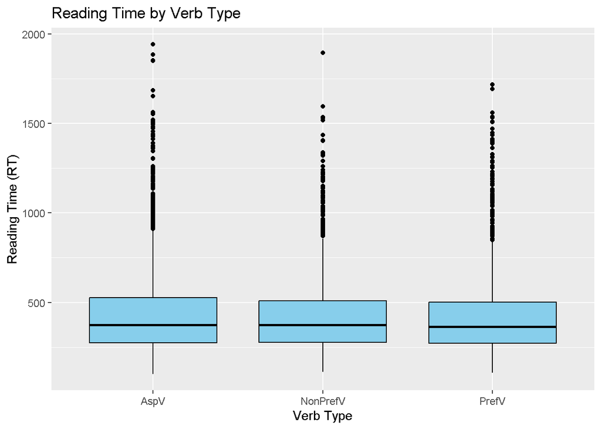

```r
longer_vt <- pivot_longer(wider_vt,
                           cols = c(AspV, PrefV, NonPrefV),
                           names_to = "VerbType",
                           values_to = "RT")

# Create a box plot of reading time by verb type
library(ggplot2)
ggplot(longer_vt, aes(x = VerbType, y = RT)) +
  geom_boxplot(fill = "skyblue", color = "black") +
  labs(x = "Verb Type", y = "Reading Time (RT)", title = "Reading Time by Verb Type")
```

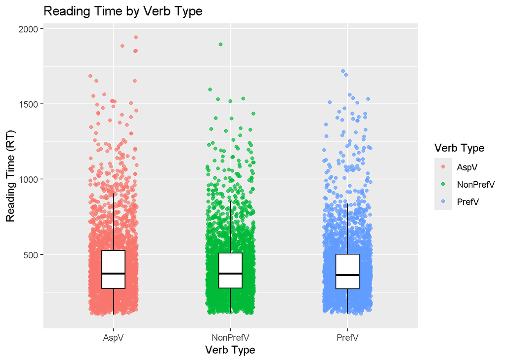

```r
ggplot(longer_vt, aes(x = VerbType, y = RT, color = VerbType)) +
  geom_jitter(width = 0.2, height = 0, alpha = 0.7) +
  geom_boxplot(width = 0.2, fill = "white", color = "black", outlier.shape = NA) +
  labs(x = "Verb Type", y = "Reading Time (RT)", color = "Verb Type", title = "Reading Time by Verb Type")
```

Two types of box plot showing the distribution of reading times for each verb type.

According to the data and plots, it appears that the distribution of reading/reaction times is relatively similar. There are no distinctive differences besides Asp Verbs having some data points that have higher reaction times.

2. How does the predictability of the noun phrase (NPPredictability) affect the processing of complement coercion sentences?

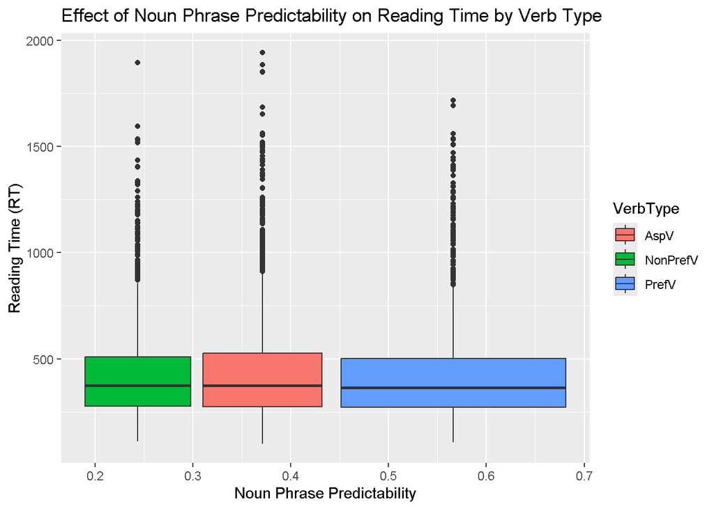

```r
ggplot(longer_vt, aes(x = NPPredictability, y = RT, fill = VerbType)) +
  geom_boxplot() +
  labs(x = "Noun Phrase Predictability", y = "Reading Time (RT)", title = "Effect of Noun Phrase Predictability on Reading Time by Verb Type")
```

Based on the data and visualizations, it seems that the distribution of reading or reaction times is largely consistent across the different verb types according to noun phrase predictability. Apart from a few instances where Asp Verbs exhibit slightly higher reaction times, there are no significant deviations observed.

3. Is there a relationship between the position of the item in the sentence (Position) and the reading time (RT)?

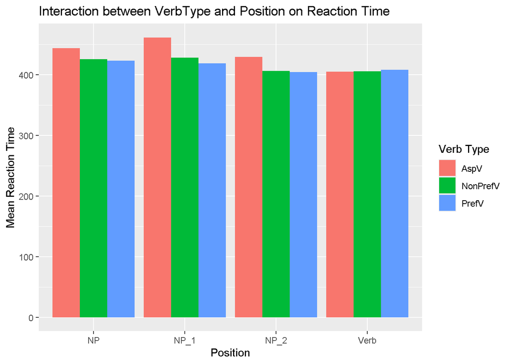

```r
ggplot(mean_rt, aes(x = Position, y = mean_RT, fill = VerbType)) +
  geom_bar(stat = "identity", position = "dodge") +
  labs(x = "Position", y = "Mean Reaction Time", fill = "Verb Type", title = "Interaction between VerbType and Position on Reaction Time")
```

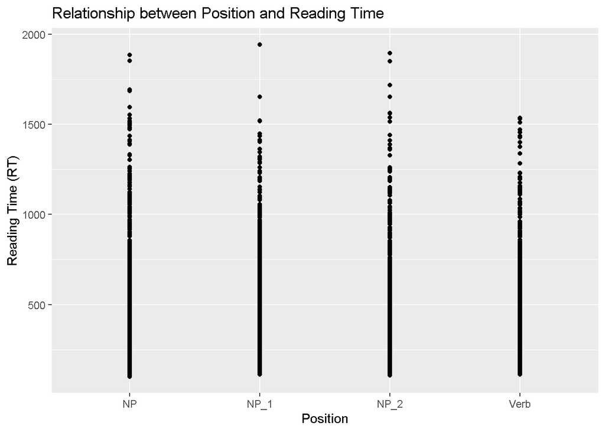

```r
ggplot(longer_vt, aes(x = Position, y = RT)) +
  geom_point() +
  labs(x = "Position", y = "Reading Time (RT)", title = "Relationship between Position and Reading Time")
```

4. How do interactions between different variables (e.g., VerbType and Position) influence participants’ reaction times?

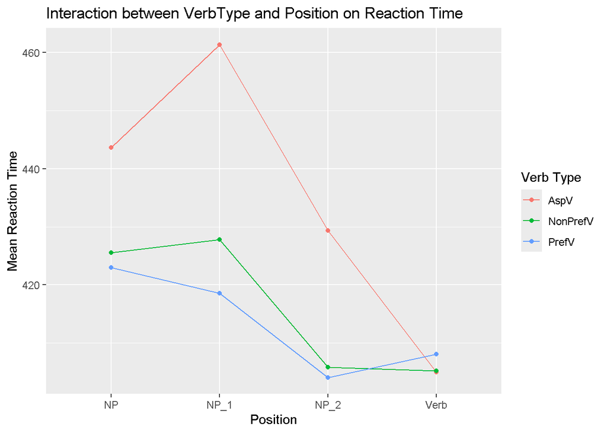

```r
mean_rt <- rest |>
  group_by(VerbType, Position) |>
  summarize(mean_RT = mean(RT))
# Create a line plot to visualize the interaction between VerbType and Position on reaction time
ggplot(mean_rt, aes(x = Position, y = mean_RT, color = VerbType, group = VerbType)) +
  geom_line() +
  geom_point() +
  labs(x = "Position", y = "Mean Reaction Time", color = "Verb Type", title = "Interaction between VerbType and Position on Reaction Time")
```